# Overview: Assignment 2

NAME: **IFEDIORAH KENECHUKWU I.**

STUDENT ID: **9052693**

### Goal:

The goal of this report is to demonstrate expertise in building and training different classes of machine learning models.

The models we will build in this report are:

1. Univariate polynomial regression models
2. Multivariate Polynomial models
3. Decision Trees
4. kNNs

Ultimately, we will try to predict the risk of diabetes progression in patients using these ML models that are trained on sklearn diabetes dataset.

**In this lab we will evaluate the models using R-squared, Mean Absolute Percentage Error (MAPE) and Mean Absolute Error (MAE) metrics.**

# 1.0 Introduction

### 1.0.1 About the Dataset

The diabetes dataset used in this report is one of sklearn's toy data set. It contains ten baseline variables, age, sex, body mass index, average blood pressure, and six blood serum measurements that were obtained for each of n = 442 diabetes patients, as well as the response of interest, a quantitative measure of disease progression one year after baseline.

**Data Set Characteristics:**

**Number of Attributes:** First 10 columns are numeric predictive values

**Target:** Column 11 is a quantitative measure of disease progression one year after baseline

**Attribute Information:**

- age (age in years)
- sex
- bmi (body mass index)
- bp (average blood pressure)
- s1 tc, (total serum cholesterol)
- s2 ldl, (low-density lipoproteins)
- s3 hdl, (high-density lipoproteins)
- s4 tch, (total cholesterol / HDL)
- s5 ltg, (possibly log of serum triglycerides level)
- s6 glu, (blood sugar level)

**Note:** Each of these 10 feature variables have been mean centered and scaled by the standard deviation times the square root of n_samples (i.e. the sum of squares of each column totals 1).

**The Problem:**

The aim is to be able to predict the the disease progression of the patient a year after the baseline data is recorded. We want to train the machine learning model to predict the risk of diabetes progression over a year. This would be a tool to help physicians with Identifying patients at risk.

### 1.0.2 Report Contents:

The report will be broken down into the following sections:

- **Data Extraction**
- **Data Exploration**
- **Data Preprocessing**
- **Modelling, Evaluation and Conclusion**
  - **Univariate Polynomial Regression**
  - **Multivariate Polynomial Models, Decision Trees, and KNNs**
- **Final Notes**

# 2.0 Data Extraction (Part 1)

### 2.0.1 Import dependent libraries

```python
# Data analysis and wrangling
import numpy as np
import pandas as pd

# Data visualization
import seaborn as sns
import matplotlib.pyplot as plt

# Machine learning
from sklearn.datasets import load_diabetes
from sklearn.linear_model import LinearRegression
from sklearn.tree import DecisionTreeRegressor
from sklearn.neighbors import KNeighborsRegressor
from sklearn.model_selection import train_test_split
import sklearn.metrics as metrics
from sklearn.preprocessing import PolynomialFeatures
```

### 2.0.2 Load the dataset

Load the dataset from sklearn using the load_diabetes module

```python
diabetes = load_diabetes(as_frame=True, scaled=True)
```

```python
# sklearn datasets always loads as bunch data type
# View the keys of the bunched data
diabetes.keys()
```

```
dict_keys(['data', 'target', 'frame', 'DESCR', 'feature_names', 'data_filename', 'target_filename', 'data_module'])
```

```python
# Extract the dataframe from the bunched data
diabetes_df = diabetes['frame']
print(diabetes_df.shape)
diabetes_df.head()
```

```
(442, 11)
```

|  | age | sex | bmi | bp | s1 | s2 | s3 | s4 | s5 | s6 | target |
| --- | --- | --- | --- | --- | --- | --- | --- | --- | --- | --- | --- |
| 0 | 0.038076 | 0.050680 | 0.061696 | 0.021872 | -0.044223 | -0.034821 | -0.043401 | -0.002592 | 0.019907 | -0.017646 | 151.0 |
| 1 | -0.001882 | -0.044642 | -0.051474 | -0.026328 | -0.008449 | -0.019163 | 0.074412 | -0.039493 | -0.068332 | -0.092204 | 75.0 |
| 2 | 0.085299 | 0.050680 | 0.044451 | -0.005670 | -0.045599 | -0.034194 | -0.032356 | -0.002592 | 0.002861 | -0.025930 | 141.0 |
| 3 | -0.089063 | -0.044642 | -0.011595 | -0.036656 | 0.012191 | 0.024991 | -0.036038 | 0.034309 | 0.022688 | -0.009362 | 206.0 |
| 4 | 0.005383 | -0.044642 | -0.036385 | 0.021872 | 0.003935 | 0.015596 | 0.008142 | -0.002592 | -0.031988 | -0.046641 | 135.0 |

**Rename the columns s1 to s6 and target for better readability**

```python
diabetes_df.rename(columns={"s1":"tc", "s2":"ldl", "s3":"hdl", "s4":"tch", "s5":"ltg", "s6":"glu", "target":"progression"}, inplace=True)
```

# 3.0 Data Exploration

A first glance at the dataset confirms there are 442 rows and 11 columns as described earlier. We'll explore the dataset further and try to discover relationships between features and insights

### 3.0.1 Statistical Summary

```python
# Check for null values
diabetes_df.info()
```

```
<class 'pandas.core.frame.DataFrame'>
RangeIndex: 442 entries, 0 to 441
Data columns (total 11 columns):
 #   Column       Non-Null Count  Dtype
---  ------       --------------  -----
 0   age          442 non-null    float64
 1   sex          442 non-null    float64
 2   bmi          442 non-null    float64
 3   bp           442 non-null    float64
 4   tc           442 non-null    float64
 5   ldl          442 non-null    float64
 6   hdl          442 non-null    float64
 7   tch          442 non-null    float64
 8   ltg          442 non-null    float64
 9   glu          442 non-null    float64
 10  progression  442 non-null    float64
dtypes: float64(11)
memory usage: 38.1 KB
```

```python
# Check out the summary statistics
diabetes_df.describe()
```

|  | age | sex | bmi | bp | tc | ldl | hdl | tch | ltg | glu | progression |
| --- | --- | --- | --- | --- | --- | --- | --- | --- | --- | --- | --- |
| count | 4.420000e+02 | 4.420000e+02 | 4.420000e+02 | 4.420000e+02 | 4.420000e+02 | 4.420000e+02 | 4.420000e+02 | 4.420000e+02 | 4.420000e+02 | 4.420000e+02 | 442.000000 |
| mean | -2.511817e-19 | 1.230790e-17 | -2.245564e-16 | -4.797570e-17 | -1.381499e-17 | 3.918434e-17 | -5.777179e-18 | -9.042540e-18 | 9.293722e-17 | 1.130318e-17 | 152.133484 |
| std | 4.761905e-02 | 4.761905e-02 | 4.761905e-02 | 4.761905e-02 | 4.761905e-02 | 4.761905e-02 | 4.761905e-02 | 4.761905e-02 | 4.761905e-02 | 4.761905e-02 | 77.093005 |
| min | -1.072256e-01 | -4.464164e-02 | -9.027530e-02 | -1.123988e-01 | -1.267807e-01 | -1.156131e-01 | -1.023071e-01 | -7.639450e-02 | -1.260971e-01 | -1.377672e-01 | 25.000000 |
| 25% | -3.729927e-02 | -4.464164e-02 | -3.422907e-02 | -3.665608e-02 | -3.424784e-02 | -3.035840e-02 | -3.511716e-02 | -3.949338e-02 | -3.324559e-02 | -3.317903e-02 | 87.000000 |
| 50% | 5.383060e-03 | -4.464164e-02 | -7.283766e-03 | -5.670422e-03 | -4.320866e-03 | -3.819065e-03 | -6.584468e-03 | -2.592262e-03 | -1.947171e-03 | -1.077698e-03 | 140.500000 |
| 75% | 3.807591e-02 | 5.068012e-02 | 3.124802e-02 | 3.564379e-02 | 2.835801e-02 | 2.984439e-02 | 2.931150e-02 | 3.430886e-02 | 3.243232e-02 | 2.791705e-02 | 211.500000 |
| max | 1.107267e-01 | 5.068012e-02 | 1.705552e-01 | 1.320436e-01 | 1.539137e-01 | 1.987880e-01 | 1.811791e-01 | 1.852344e-01 | 1.335973e-01 | 1.356118e-01 | 346.000000 |

**Observation:**

As stated earlier, while importing the dataset, we used the `scaled` option, which scalled all the features of the dataset using the mean and the standard deviation. Each of the 10 feature variables have been mean centered and scaled by the standard deviation times the square root of n_samples.

*Because the features of the dataset has been scaled, we can't really make much sence of the features from a glance at the summary statistics. From the summary of the target variable, we can't detect the presence of outlier variables. We can further explore relationships and structure of the distribution by plotting some charts.*

### 3.0.2 Data Visualizations

**Use Charts to explore distributions and relationships**

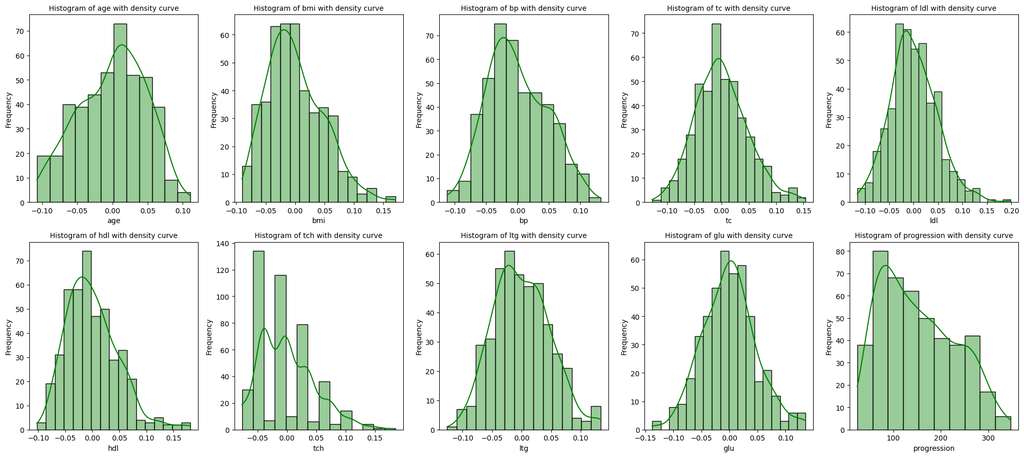

```python
## Plot a histogram with density curve of all the features and target to view the distribution
fig, axes = plt.subplots(2, 5, figsize=(20, 9))

# Iterate over the columns in the dataset and plot the histogram
for col, ax in zip(diabetes_df.columns.drop("sex"), axes.ravel()):
    # Drop the sex column because it is a binary categorical column and a histogram would not give any information on it
    sns.histplot(diabetes_df[col], ax = ax, kde=True, color="green", alpha=0.4)
    ax.set_title(f"Histogram of {col} with density curve", fontsize = 10)
    ax.set_ylabel("Frequency", fontsize = 10)
    ax.set_xlabel(col)

plt.tight_layout()
plt.plot();
```

**Observations:**

- `Total Serum Cholesterol (tc)`, `blood sugar level (glu)`, `high density lipoproteins (hdl)` and `low density lipoproteins (ldl)` follow and almost normal distribution, with a very slight skew to the right for tc, hdl, and ldl and to the left for glu
- `age`, `log of serum triglycerides level (ltg)`, `bmi`, and `bp` show some slight deviations from the ideal normal distribution but are not far off
- `Total Cholesterol/HDL (tch)` shows a multimodal distribution and the target variable, `disease progression` a skewed distribution

Next, we'll examine the relationships between the features and then use scatter plots to try and visualise the individual relationships with the target variables

### 3.0.3 Correlation and Relationships

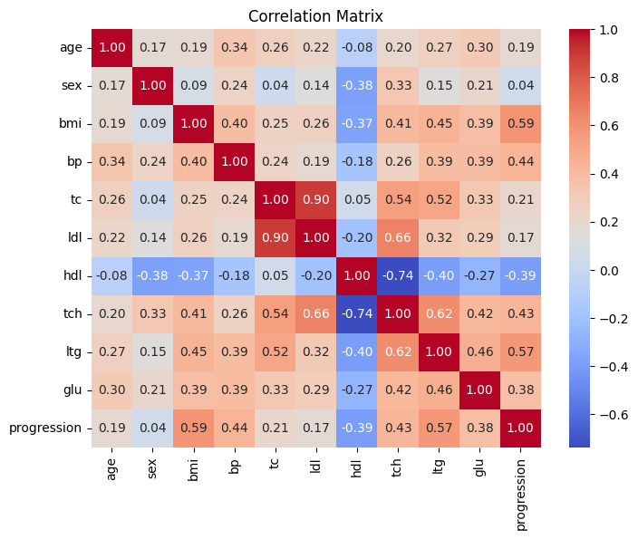

```python
# Compute the correlation matrix
corr_matrix = diabetes_df.corr()

# Plot the matrix
plt.figure(figsize=(8, 6))
sns.heatmap(corr_matrix, annot=True, cmap="coolwarm", fmt=".2f")

plt.title("Correlation Matrix")
plt.show()
```

**Observations:** Let's focus a bit on the target variable "progression". The correlation between the features and the target variable in order of strength are: **TOP FIVE:**

- bmi 0.59
- ltg 0.57
- bp 0.44
- tch 0.43
- hdl -0.39

This implies that `bmi` ans `ltg` has more individual correlation with the target variables than tthe other features. This means that these features have a greater influence on determining the risk of disease progression in these patients than other features like `sex` for example with a correlation of 0.04 which means that the sex of the patient is a negligible factor when determining the the risk level of th disease progression in that patient.

Some features are highly correlated with each other like `tc` and `ldl` with a corrwelation of **0.9**, `hdl` and `tch` with a correlation of **-0.74**, etc. This could be because of interdependence of the features, for example, tch is `Total Cholestorol/HDL`, it only makes sense for the values to be inter-related with the HDL values. There might be other medical explanations for this, but we do not have enough information to conclude and it is not in the scope of this report.

These relationships can also be visualised using the pairplot

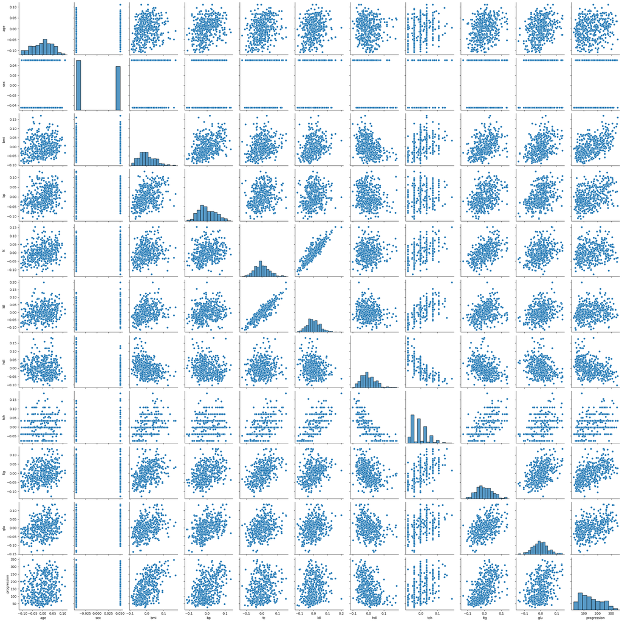

```python
# Visualise using pairplot
sns.pairplot(diabetes_df)
```

# 4.0 Data Preprocessing

Having explored the dataset, we have not found any irregularities or unusual values. We would go ahead to split the data into training, validation and testing sets to prepare for model training.

We do not have to perform any cleaning as the dataset is is already clean and tidy enough. The only cleaning we had to do was the renaming of columns done earlier in the data extraction section.

### 4.0.1 Splitting the dataset

We start by fitting the model on just the BMI feature and the target variable, progression.

We'll split the data in the ratio 75, 10, 15. 75% for training, 10% for validation, and 15% for testing set.

```python
X = diabetes_df[['bmi']]
y = diabetes_df['progression']

# First split the data into training and temp sets
X_train, X_temp, y_train, y_temp = train_test_split(X, y, test_size=0.25, random_state=42)
```

```python
# Split the temp sets into testing and validation sets
X_val, X_test, y_val, y_test = train_test_split(X_temp, y_temp, test_size=0.60, random_state=42)
```

# 5.0 Modelling, Evaluation and Conclusion (Part 2)

### 5.0.1 Univariate Polynomial Regression

First, we'll train a univariate polynomial regression model on the BMI feature versus the "disease progression one year after baseline" - from degree 0 to 5.

##### i. Train and evaluate 6 models of degree 0-5

```python
# Initialize dictionary to store models and their properties for use outside the loop
models = {}

# Loop over the reange of degrees and define polynomial model for each degree
for degree in range(0,6):
    # declare model key in dictionary
    models[f"model_{degree}"] = {}
    if degree == 0:
        polynomial = PolynomialFeatures(degree=degree)
    else:
        # No need to introduce noice if degree is not equal to zero
        polynomial = PolynomialFeatures(degree=degree, include_bias=False)

    # fit the model to a polynomial olf the degree specified
    X_poly_train = polynomial.fit_transform(X_train)
    feature_names = polynomial.get_feature_names_out()

    # Save feature names and polynomial in dictionary
    models[f"model_{degree}"]["feature_names"] = feature_names
    models[f"model_{degree}"]["polynomial"] = polynomial

    # Initialize the Linear Regression Model
    model = LinearRegression()

    # Fit Model using the transformed X train values and y train
    model.fit(X_poly_train, y_train)

    # save the model in the dictionary for use outside the loop
    models[f"model_{degree}"]["model"] = model

    # Use the model to predict the train values, evaluate and store the model metrics
    y_poly_train_pred = model.predict(X_poly_train)

    models[f"model_{degree}"]["r2_score_train"] = metrics.r2_score(y_train, y_poly_train_pred)
    models[f"model_{degree}"]["mae_train"] = metrics.mean_absolute_error(y_train, y_poly_train_pred)
    models[f"model_{degree}"]["mape_train"] = metrics.mean_absolute_percentage_error(y_train, y_poly_train_pred)

    # Use the model to predict the validation values, evaluate and store the model metrics
    # We use polynomial.transform to transform the validation dataset into a form that the model understands
    # because the model was fitted with the transformed X_train values
    y_poly_val_pred = model.predict(polynomial.transform(X_val))

    models[f"model_{degree}"]["r2_score_val"] = metrics.r2_score(y_val, y_poly_val_pred)
    models[f"model_{degree}"]["mae_val"] = metrics.mean_absolute_error(y_val, y_poly_val_pred)
    models[f"model_{degree}"]["mape_val"] = metrics.mean_absolute_percentage_error(y_val, y_poly_val_pred)
```

#### ii. Display training and validation results in a table

```python
# Create table with model evaluation metrics

model_properties = pd.DataFrame.from_dict(models, orient="index")
```

```python
# Display the metrics table
model_properties[["r2_score_train", "mae_train", "mape_train", "r2_score_val", "mae_val", "mape_val"]]
```

|  | r2_score_train | mae_train | mape_train | r2_score_val | mae_val | mape_val |
| --- | --- | --- | --- | --- | --- | --- |
| model_0 | 0.000000 | 66.201641 | 0.628267 | -0.106957 | 66.057059 | 0.712639 |
| model_1 | 0.349672 | 52.287739 | 0.483629 | 0.331264 | 47.208472 | 0.470600 |
| model_2 | 0.350764 | 52.207314 | 0.482985 | 0.331631 | 47.213700 | 0.472397 |
| model_3 | 0.350774 | 52.198968 | 0.482807 | 0.331638 | 47.185414 | 0.472227 |
| model_4 | 0.353014 | 52.092653 | 0.480533 | 0.340758 | 46.090118 | 0.460503 |
| model_5 | 0.354100 | 52.059191 | 0.480040 | 0.349881 | 45.462121 | 0.451753 |

#### iii. Identify the best model

**The best model of the 6 models trained above is model 5 (i.e the model with degree 5)**

**Justification:**

- `Model 5` has the highest R-Squared score of `0.354100`. For R-Squared score, **Higher is better.**,Since R-Squared score is the measure of how much variance in the data is explained by the model, this means that model 5 explains the variance in the data more than all other models.
- `Model 5` has the lowest `MAE` and `MAPE`. For error metrics like MAE and MAPE, **Lower is better.**, Since our aim is to minimize the residuals between the actual and predicted values, the model with the lower error metric is considered better.

#### iv. Run the chosen model on the test set and provide results (R-Squared, MAPE, MAE)

```python
# Retrieve Model 5 and the polynomial from the models dictionary
model5 = models['model_5']['model']
polynomial_model5 = models['model_5']['polynomial']
y_pred_model5 = model5.predict(polynomial_model5.transform(X_test))

# Evalueate R-Squares, MAE and MAPE for the test set
r2_score_test_model5 = metrics.r2_score(y_test, y_pred_model5)
mae_test_model5 = metrics.mean_absolute_error(y_test, y_pred_model5)
mape_test_model5 = metrics.mean_absolute_percentage_error(y_test, y_pred_model5)

print(f"r2_score = {r2_score_test_model5}")
print(f"Mean Absolute Error = {mae_test_model5}")
print(f"Mean Absolute Percentage Error = {mape_test_model5}")
```

```
r2_score = 0.2666965844953081
Mean Absolute Error = 51.750257092773964
Mean Absolute Percentage Error = 0.43026713233054414
```

#### v. Plot a graph of the train, validation and test data points, and the fit of the chosen model over each of them

[output not shown]

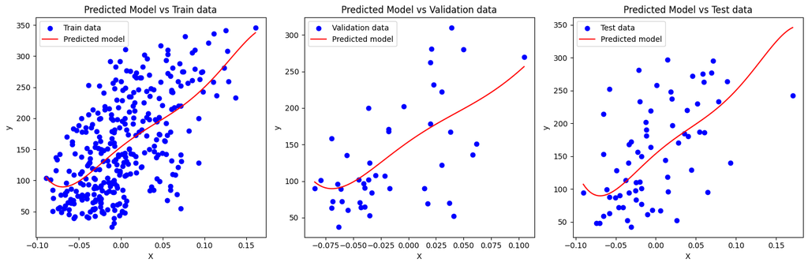

```python
# Declare the plot figure
fig, axes = plt.subplots(1, 3, figsize = (15, 5))


# Generate a new set of points ranging from X_min to X_max for train data so we can fit the polynomial curve
X_new_train = np.linspace(X_train.min(), X_train.max(), 100).reshape(100, 1)
X_new_poly_train = polynomial_model5.transform(X_new_train)     # Transform the data using the model polynomial feature
y_new_train = model5.predict(X_new_poly_train)                  # Use the model to predict the y values of the new points
axes[0].scatter(X_train, y_train, color="blue", label="Train data")
axes[0].plot(X_new_train, y_new_train, color="red", label="Predicted model")
axes[0].set_title("Predicted Model vs Train data")
axes[0].set_ylabel("y")
axes[0].set_xlabel("X")
axes[0].legend(loc="upper left", fontsize=10)


# Generate a new set of points ranging from X_min to X_max for validation data so we can fit the polynomial curve
X_new_val = np.linspace(X_val.min(), X_val.max(), 100).reshape(100, 1)
X_new_poly_val = polynomial_model5.transform(X_new_val)       # Transform the data using the model polynomial feature
y_new_val = model5.predict(X_new_poly_val)                      # Use the model to predict the y values of the new points
axes[1].scatter(X_val, y_val, color="blue", label="Validation data")
axes[1].plot(X_new_val, y_new_val, color="red", label="Predicted model")
axes[1].set_title("Predicted Model vs Validation data")
axes[1].set_ylabel("y")
axes[1].set_xlabel("X")
axes[1].legend(loc="upper left", fontsize=10)


# Generate a new set of points ranging from X_min to X_max for test data so we can fit the polynomial curve
X_new_test = np.linspace(X_test.min(), X_test.max(), 100).reshape(100, 1)
X_new_poly_test = polynomial_model5.transform(X_new_test)       # Transform the data using the model polynomial feature
y_new_test = model5.predict(X_new_poly_test)                    # Use the model to predict the y values of the new points
axes[2].scatter(X_test, y_test, color="blue", label="Test data")
axes[2].plot(X_new_test, y_new_test, color="red", label="Predicted model")
axes[2].set_title("Predicted Model vs Test data")
axes[2].set_ylabel("y")
axes[2].set_xlabel("X")
axes[2].legend(loc="upper left", fontsize=10)

plt.tight_layout()
plt.show()
```

#### vi. Write down the equation of the best model (with a two decimal digit precision, assuming it's sufficient)

```python
# generate equation string:
equation = f"y = {model5.intercept_:.2f}"
for ind, coeff in enumerate(model5.coef_):
    degree = ind + 1
    if coeff < 0:
        equation += f" - {abs(coeff):.2f}bmi^{degree}"
    else:
        equation += f" + {abs(coeff):.2f}bmi^{degree}"
print(f'Equation: {equation}')
```

```
Equation: y = 153.65 + 1059.89bmi^1 - 3824.15bmi^2 - 16770.23bmi^3 + 753722.52bmi^4 - 2993716.57bmi^5
```

#### vii. Calculate the expected diabetes progression for a BMI value of your choice using `model.predict()` for that value

```python
expected_progression = model5.predict(polynomial_model5.transform([[0.08]]))
print(f"The model prediction for scaled BMI value of 0.08 is {float(expected_progression[0])}")
```

```
The model prediction for scaled BMI value of 0.08 is 226.44773163965448
```

[output not shown]

#### viii. How many trainable parameters are we fitting for each of the models? Explain these values.

**Trainable Parameters per model**

```python
for key in models.keys():
    print(f"{key}: {models[key]["feature_names"]}")
```

```
model_0: ['1']
model_1: ['bmi']
model_2: ['bmi' 'bmi^2']
model_3: ['bmi' 'bmi^2' 'bmi^3']
model_4: ['bmi' 'bmi^2' 'bmi^3' 'bmi^4']
model_5: ['bmi' 'bmi^2' 'bmi^3' 'bmi^4' 'bmi^5']
```

These trainable parameters represent the features used in each of the polynomial regression model trained above.

**Understanding the Features in Each Model**

1. `model_0`: ['1']
   - This means the model only includes an intercept (bias term) with no actual bmi feature. This is the baseline model that predicts the a constant value for all inputs.
   - Equation: $y = w_0$
2. `model_1`: ['bmi'] --> Fitting one feature
   - This is a linear model that includes only the bmi feature.
   - Equation: $y = w_0 + w_1bmi$
   - This model assumes a straight-line relationship between bmi and the target variable.
3. `model_2`: ['bmi' 'bmi^2'] --> Fitting two features
   - This introduces a quadratic term (bmi^2)
   - Equation: $y = w_0 + w_1bmi + w_2bmi^2$
   - This allows the model to capture curvature in the data.
4. `model_3`: ['bmi' 'bmi^2' 'bmi^3'] --> Fitting three features
   - This extends the model to cubic regression (third-degree polynomial) by introducing (bmi^3)
   - Equation: $y = w_0 + w_1bmi + w_2bmi^2 + w_3bmi^3$
   - This can model more complex relationships, including one inflection point
5. `model_4`: ['bmi' 'bmi^2' 'bmi^3' 'bmi^4'] --> Fitting four features
   - This is a fourth-degree polynomial
   - Equation: $y = w_0 + w_1bmi + w_2bmi^2 + w_3bmi^3 + w_4bmi^4$
   - It can fit even more complex curves
6. `model_5`: ['bmi' 'bmi^2' 'bmi^3' 'bmi^4' 'bmi^5'] --> Fitting five features
   - This is a fifth-degree polynomial
   - Equation: $y = w_0 + w_1bmi + w_2bmi^2 + w_3bmi^3 + w_4bmi^4 + w_5bmi^5$
   - It provides even more flexibility

#### ix. Provide a Conclusion section

**CONCLUSION: UNIVARIATE POLYNOMIAL REGRESSION**

**Performance Summary:** `Model_5` performed best of the 6 models trained. Model_5 is a univariate polynomial model with degree of 5. Here are the performance metrics on the testing dataset.

- R-Squared: 0.27
- Mean Absolute Error: 51.75
- Mean Absolute Percentage Error: 0.43 or 43.02%

While this model performed best of the 6 models trained, we cannot say that the model performed well because the performance metrics do not inspire confidence.

R-Squared value of 0.27 means that only about 27% of the variance in the target data is explained by the model. This is very low, because over 70% of the variance is not explained.

Also, A Mean Absolute Percentage Error of about 43% means that almost half of the time, we would be predicting the output variable wrongly.

Since this model is to be used in determining the risk likelihood for patients, which is a critical issue, it would not be wise to deploy a model with such high error margins.

**Limitations and Failures:**

- Higher-degree polynomial models tend to lose explainability because of the higher orders that are added in the equation, making them less practical in real-world applications.
- We notice that as we increased the order, the model performance metrics kept increasing slightly, this might eventually lead to overfitting and the model not being able to generalize to new data

**To improve performance, we can consider including other additional features from the original dataset, or changing the ML algorithm used. This will be done in the next sections**

### 5.0.2: Multivariate Polynomial Models, Decision Trees, and KNNs (Part 3)

In this section, we will train multivariate polynomial models, decision trees and KNNs on the same data and evaluate the performance of the models, then we will compare.

*Note: For this section, we will be training the models using all the features in the dataset*

**Define X and Y again**

```python
X = diabetes_df[diabetes_df.columns.drop('progression')]
y = diabetes_df['progression']
```

**Split data into Training, Validation and Testing sets**

```python
# First split the data into training and temp sets
X_train, X_temp, y_train, y_temp = train_test_split(X, y, test_size=0.25, random_state=42)

# Split the temp sets into testing and validation sets
X_val, X_test, y_val, y_test = train_test_split(X_temp, y_temp, test_size=0.60, random_state=42)
```

#### a. Polynomial Models

We will train two Polynomial models of degrees 2 and 3

##### i. Train and Evaluate the Models

```python
# Initialize dictionary to store models and their properties for use outside the loop
poly_models = {}

# Loop over the reange of degrees and define polynomial model for each degree
for degree in [2,3]:
    # declare model key in dictionary
    poly_models[f"model_{degree}"] = {}

    polynomial = PolynomialFeatures(degree=degree, include_bias=False)

    # fit the model to a polynomial of the degree specified
    X_poly_train = polynomial.fit_transform(X_train)
    feature_names = polynomial.get_feature_names_out()

    # Save feature names and polynomial in dictionary
    poly_models[f"model_{degree}"]["feature_names"] = feature_names
    poly_models[f"model_{degree}"]["polynomial"] = polynomial

    # Initialize the Linear Regression Model
    poly_model = LinearRegression()

    # Fit Model using the transformed X train values and y train
    poly_model.fit(X_poly_train, y_train)

    # save the model in the dictionary for use outside the loop
    poly_models[f"model_{degree}"]["model"] = poly_model

    # Use the model to predict the train values, evaluate and store the model metrics
    y_poly_train_pred = poly_model.predict(X_poly_train)

    poly_models[f"model_{degree}"]["r2_score_train"] = metrics.r2_score(y_train, y_poly_train_pred)
    poly_models[f"model_{degree}"]["mae_train"] = metrics.mean_absolute_error(y_train, y_poly_train_pred)
    poly_models[f"model_{degree}"]["mape_train"] = metrics.mean_absolute_percentage_error(y_train, y_poly_train_pred)

    # Use the model to predict the validation values, evaluate and store the model metrics
    # We use polynomial.transform to transform the validation dataset into a form that the model understands
    # because the model was fitted with the transformed X_train values
    y_poly_val_pred = poly_model.predict(polynomial.transform(X_val))

    poly_models[f"model_{degree}"]["r2_score_val"] = metrics.r2_score(y_val, y_poly_val_pred)
    poly_models[f"model_{degree}"]["mae_val"] = metrics.mean_absolute_error(y_val, y_poly_val_pred)
    poly_models[f"model_{degree}"]["mape_val"] = metrics.mean_absolute_percentage_error(y_val, y_poly_val_pred)
```

##### ii. Display training and validation results in a table

```python
# Create table with model evaluation metrics

poly_model_properties = pd.DataFrame.from_dict(poly_models, orient="index")

# Display the metrics table
poly_model_properties[["r2_score_train", "mae_train", "mape_train", "r2_score_val", "mae_val", "mape_val"]]
```

|  | r2_score_train | mae_train | mape_train | r2_score_val | mae_val | mape_val |
| --- | --- | --- | --- | --- | --- | --- |
| model_2 | 0.604815 | 39.215776 | 0.346057 | 0.426319 | 41.802033 | 0.422773 |
| model_3 | 0.909838 | 15.649903 | 0.143547 | -43.331310 | 241.282498 | 2.312837 |

##### iii. Identify the best model

**Key Observations:**

- The R-Sqauared value for model_3 is very high and it also has very low MAE and MAPE scores compared model_2 for the training set. For the validation set, the R-Squared,MAPE and MAE are extremely very poor with R-Squared value of -43.33, MAE of 241.28 and MAPE of 2.31.
- **This suggests that model_3 is *overfitting* on the training data and will perform very poorly on unseen data**
- model_2 is more generalizable because even though it's performance metrics is not as good as model_3 on the training data set, it has a reasonable balance between training and validation perfomance. This means that model_2 is able to capture meaningful patterns in the data without overfitting

**Model 2 (Polynomial degree = 2) is the better model because it generalizes to new data while Model 3 extremely overfits the data**

##### iv. Run the chosen model on the test set and provide results (R-Squared, MAPE, MAE)

```python
# Retrieve Model 2 and the polynomial from the models dictionary
poly_model2 = poly_models['model_2']['model']
polynomial_poly_model2 = poly_models['model_2']['polynomial']
y_pred_poly_model2 = poly_model2.predict(polynomial_poly_model2.transform(X_test))

# Evalueate R-Squares, MAE and MAPE for the test set
r2_score_test_poly_model2 = metrics.r2_score(y_test, y_pred_poly_model2)
mae_test_poly_model2 = metrics.mean_absolute_error(y_test, y_pred_poly_model2)
mape_test_poly_model2 = metrics.mean_absolute_percentage_error(y_test, y_pred_poly_model2)

print(f"r2_score = {r2_score_test_poly_model2}")
print(f"Mean Absolute Error = {mae_test_poly_model2}")
print(f"Mean Absolute Percentage Error = {mape_test_poly_model2}")
```

```
r2_score = 0.39939206922599413
Mean Absolute Error = 45.49306091436776
Mean Absolute Percentage Error = 0.37948549864831066
```

##### v. Write down the equation of the best model (with a two decimal digit precision, assuming it's sufficient)

```python
# generate equation string:
equation_poly = f"y = {poly_model2.intercept_:.2f}"
for coeff, feature in zip(poly_model2.coef_,poly_models['model_2']['feature_names']):
    if coeff < 0:
        equation_poly += f" - {abs(coeff):.2f}{feature.replace(" ","")}"
    else:
        equation_poly += f" + {abs(coeff):.2f}{feature.replace(" ","")}"
print(f'Equation: {equation_poly}')
```

[output not shown]

**Observation:**

The equation is too long because we fit the polynomial model with all 10 features and it is to the order of 2. So we have about 65 combination of features.

##### vi. How many trainable parameters are we fitting for each of the models? Explain these values.

```python
for key in poly_models.keys():
    print(f"{key}: {poly_models[key]["feature_names"].shape}")
```

```
model_2: (65,)
model_3: (285,)
```

**For Model_2, we are fitting 65 features**

**For Model_3, we are fitting 285 features**

##### vii. Provide a Conclusion

**CONCLUSION: MULTIVARIATE POLYNOMIAL REGRESSION**

**Performance Summary:** `Model_2` performed better of the 2 models trained. Model_2 is a multivariate polynomial model with degree of 2. Here are the performance metrics on the testing dataset.

- R-Squared: 0.399
- Mean Absolute Error: 45.49
- Mean Absolute Percentage Error: 0.37 or 37.95%

**Key Note: This model performed better than the Univariate model we trained earlier with an increase in R-Squared of almost 0.13 and a reduction in MAPE of about 5%**

While this model performed better of the 2 multivariate models trained, and even better than the univariate model trained ealier, we still cannot completely accept this model performance in a critical area such as disease risk prediction because the performance metrics still do not inspire enough confidence.

The model achieved an R-Squared value of 0.399, indicating that it explains approximately 39.9% of the variance in the target variable. While this suggests some predictive power, a significant portion of variability remains unexplained. The Mean Absolute Percentage Error (MAPE) of 37.95% implies that the model's predictions have an average error of around 38% relative to the true values.

The MAE of 45.49 indicates that errors are still relatively large, which could be problematic in critical applications like disease risk prediction where a lot is riding on the decision and some level of precision is required.

The current model provides a basic risk assessment but is not reliable enough for critical medical decisions. Significant improvements are necessary before it can be safely used in patient risk prediction.

**Limitations and Failures:**

- High error metrics.
- Relatively low R-Squared value suggests that the model is not capturing all the patterns in the data. Just maybe a polynomial model is not the best for our dataset.

**To try and improve performance, we will change the ML algorithm used. We will try using a Decision Tree Model**

#### b. Decision Tree Models

In this section, we will train two decision tree models on the same data and evaluate the performance of the models, then we will compare.

`max_depth` is a hyperparameter in decision tree models that controls the maximum depth of the tree. It determines how many levels of splitting are allowed from the root node to the deepest leaf node.

##### i. Train and evaluate the models

```python
# Initialize dictionary to store models and their properties for use outside the loop
tree_models = {}

# Loop over the list of max_depth and define decision tree model for each depth
for depth in [2, 3]:
    # declare model key in dictionary
    tree_models[f"model_{depth}"] = {}

    # Initialize the Decision Tree Regression Model
    tree_model = DecisionTreeRegressor(max_depth=depth, random_state=42)

    # Fit Model using the X train values and y train
    tree_model.fit(X_train, y_train)

    # save the model in the dictionary for use outside the loop
    tree_models[f"model_{depth}"]["model"] = tree_model

    # Use the model to predict the train values, evaluate and store the model metrics
    y_tree_train_pred = tree_model.predict(X_train)

    tree_models[f"model_{depth}"]["r2_score_train"] = metrics.r2_score(y_train, y_tree_train_pred)
    tree_models[f"model_{depth}"]["mae_train"] = metrics.mean_absolute_error(y_train, y_tree_train_pred)
    tree_models[f"model_{depth}"]["mape_train"] = metrics.mean_absolute_percentage_error(y_train, y_tree_train_pred)

    # Use the model to predict the validation values, evaluate and store the model metrics
    y_tree_val_pred = tree_model.predict(X_val)

    tree_models[f"model_{depth}"]["r2_score_val"] = metrics.r2_score(y_val, y_tree_val_pred)
    tree_models[f"model_{depth}"]["mae_val"] = metrics.mean_absolute_error(y_val, y_tree_val_pred)
    tree_models[f"model_{depth}"]["mape_val"] = metrics.mean_absolute_percentage_error(y_val, y_tree_val_pred)
```

##### ii. Display training and validation results in a table

```python
# Create table with model evaluation metrics

tree_model_properties = pd.DataFrame.from_dict(tree_models, orient="index")

# Display the metrics table
tree_model_properties[["r2_score_train", "mae_train", "mape_train", "r2_score_val", "mae_val", "mape_val"]]
```

|  | r2_score_train | mae_train | mape_train | r2_score_val | mae_val | mape_val |
| --- | --- | --- | --- | --- | --- | --- |
| model_2 | 0.438054 | 47.996013 | 0.424809 | 0.308988 | 45.801381 | 0.476091 |
| model_3 | 0.509503 | 44.259855 | 0.388666 | 0.198306 | 48.126248 | 0.476729 |

##### iii. Identify the best model

**Key Observations:**

- The R-Sqauared value for model_3 is a bit higher than that of model_2 and it also has lower MAE and MAPE scores compared model_2 for the training set. For the validation set, the R-Squared is extremely poor (0.19) compared to model_2 (0.31), the MAPE and MAE are also slightly higher than that of model_2.
- **This suggests that model_3 is *overfitting* on the training data and will perform poorly on unseen data**
- model_2 is more generalizable because even though it's performance metrics is not as good as model_3 on the training data set, it has a reasonable balance between training and validation perfomance. This means that model_2 is able to capture meaningful patterns in the data without overfitting

**Model 2 (max_depth = 2) is the better model because it generalizes to new data while Model 3 extremely overfits the data**

##### iv. Run the chosen model on the test set and provide results (R-Squared, MAPE, MAE)

```python
# Retrieve Model 2 and the polynomial from the models dictionary
tree_model2 = tree_models['model_2']['model']
y_pred_tree_model2 = tree_model2.predict(X_test)

# Evalueate R-Squares, MAE and MAPE for the test set
r2_score_test_tree_model2 = metrics.r2_score(y_test, y_pred_tree_model2)
mae_test_tree_model2 = metrics.mean_absolute_error(y_test, y_pred_tree_model2)
mape_test_tree_model2 = metrics.mean_absolute_percentage_error(y_test, y_pred_tree_model2)

print(f"r2_score = {r2_score_test_tree_model2}")
print(f"Mean Absolute Error = {mae_test_tree_model2}")
print(f"Mean Absolute Percentage Error = {mape_test_tree_model2}")
```

```
r2_score = 0.3622177309389697
Mean Absolute Error = 48.34020278685211
Mean Absolute Percentage Error = 0.41856889606151276
```

**Observation:**

The model performs a bit better on the testing set when compared to the validation set. This confirms that the model generalizes very well to unseen data.

Decision trees do not have a linear equation form. They have a set of if else conditions that the model uses to make decisions at different decision boundaries

##### v. How many trainable parameters are we fitting for each of the models?

For a Decision Tree Regressor, the number of trainable parameters corresponds to the number of decision nodes and leaf nodes in the tree.

The total number of trainable parameters in a decision tree includes:

- Number of splits (internal nodes): Each split is based on a feature and a threshold value.
- Number of leaf nodes: Each leaf contains a predicted value.

```python
for model_num in tree_models.keys():
    number_of_nodes = tree_models[model_num]['model'].tree_.node_count  # Total nodes (splits + leaves)
    number_of_splits = tree_models[model_num]['model'].tree_.n_node_samples.shape[0] - tree_models[model_num]['model'].tree_.n_leaves  # Internal decision nodes
    number_of_leaves = tree_models[model_num]['model'].tree_.n_leaves  # Leaf nodes

    print(f"Trainable Parameters for {model_num}: ")
    print(f"Total Nodes: {number_of_nodes}")
    print(f"Number of Splits (Trainable Parameters): {number_of_splits}")
    print(f"Number of Leaf Nodes: {number_of_leaves} \n\n")
```

```
Trainable Parameters for model_2:
Total Nodes: 7
Number of Splits (Trainable Parameters): 3
Number of Leaf Nodes: 4


Trainable Parameters for model_3:
Total Nodes: 15
Number of Splits (Trainable Parameters): 7
Number of Leaf Nodes: 8
```

##### vi. Provide a Conclusion

**CONCLUSION: DECISION TREE REGRESSOR MODELS**

**Performance Summary:** `Model_2` performed better of the 2 models trained. Model_2 is a Decision Tree Regressor model with max_depth parameter of 2. Here are the performance metrics on the testing dataset.

- R-Squared: 0.36
- Mean Absolute Error: 48.34
- Mean Absolute Percentage Error: 0.42 or 41.85%

**Key Note: This model performed worse than the Multivariate Polynomial model we trained earlier with a decrase in R-Squared of about 0.03 and an increase in MAPE of about 4%. This evaluation metrics means that it still performed better than the Univariate Polynomial Model we traind at the beginning**

While this model performed better of the 2 decision tree models trained, it performed worse than the multivariate model trained ealier, and we also cannot accept this model performance in a critical area such as disease risk prediction because the performance metrics still do not inspire enough confidence

The model achieved an R-Squared value of 0.36, indicating that it explains approximately 36% of the variance in the target variable. While this suggests some predictive power, a significant portion of variability remains unexplained. The Mean Absolute Percentage Error (MAPE) of 42% implies that the model's predictions have an average error of around 42% relative to the true values.

This could be problematic in critical applications like disease risk prediction where a lot is riding on the decision and some level of precision is required.

The current model may provide a basic risk assessment but is not reliable enough for critical medical decisions. Significant improvements are necessary before it can be safely used in patient risk prediction.

**Limitations and Failures:**

- High error metrics.
- Relatively low R-Squared value suggests that the model is not capturing all the patterns in the data.

**To try and improve performance, we will change the ML algorithm used. We will try using a K-Nearest-Neighbor Model**

#### c. K-Nearest-Neighbor (KNN) Models

In this section, we will train two KNN models on the same data and evaluate the performance of the models, then we will compare.

We will train two models varying the value of k. we will try out k = 3 and k = 5.

`K` represents the number of nearest neighbors considered when making a prediction. It is a hyperparameter that controls the model’s complexity and generalization ability.

##### i. Train and evaluate the models

```python
# Initialize dictionary to store models and their properties for use outside the loop
knn_models = {}

# Loop over the list of Ks and define KNN model for each value of K
for k in [3,5]:
    # declare model key in dictionary
    knn_models[f"model_{k}"] = {}

    # Initialize the KNN Regression Model
    knn_model = KNeighborsRegressor(n_neighbors=k)

    # Fit Model using the X train values and y train
    knn_model.fit(X_train, y_train)

    # save the model in the dictionary for use outside the loop
    knn_models[f"model_{k}"]["model"] = knn_model

    # Use the model to predict the train values, evaluate and store the model metrics
    y_knn_train_pred = knn_model.predict(X_train)

    knn_models[f"model_{k}"]["r2_score_train"] = metrics.r2_score(y_train, y_knn_train_pred)
    knn_models[f"model_{k}"]["mae_train"] = metrics.mean_absolute_error(y_train, y_knn_train_pred)
    knn_models[f"model_{k}"]["mape_train"] = metrics.mean_absolute_percentage_error(y_train, y_knn_train_pred)

    # Use the model to predict the validation values, evaluate and store the model metrics
    y_knn_val_pred = knn_model.predict(X_val)

    knn_models[f"model_{k}"]["r2_score_val"] = metrics.r2_score(y_val, y_knn_val_pred)
    knn_models[f"model_{k}"]["mae_val"] = metrics.mean_absolute_error(y_val, y_knn_val_pred)
    knn_models[f"model_{k}"]["mape_val"] = metrics.mean_absolute_percentage_error(y_val, y_knn_val_pred)
```

##### ii. Display training and validation results in a table

```python
# Create table with model evaluation metrics

knn_model_properties = pd.DataFrame.from_dict(knn_models, orient="index")

# Display the metrics table
knn_model_properties[["r2_score_train", "mae_train", "mape_train", "r2_score_val", "mae_val", "mape_val"]]
```

|  | r2_score_train | mae_train | mape_train | r2_score_val | mae_val | mape_val |
| --- | --- | --- | --- | --- | --- | --- |
| model_3 | 0.629300 | 37.137966 | 0.315974 | 0.214184 | 45.795455 | 0.442421 |
| model_5 | 0.570761 | 40.773414 | 0.349769 | 0.358481 | 43.290909 | 0.412441 |

##### iii. Identify the best model

**Key Observations:**

- The R-Sqauared value for model_3 is a bit higher than that of model_5 and it also has lower MAE and MAPE scores compared model_5 for the training set. For the validation set, the R-Squared is extremely poor (0.21) compared to training set (0.62), the MAPE and MAE are also higher than the traing set results. model_5 however performs better on the testing set and shows more balance between testing and training set results.
- **This suggests that model_3 is *overfitting* on the training data and will perform poorly on unseen data**
- model_5 is more generalizable because even though it's performance metrics is not as good as model_3 on the training data set, it has a reasonable balance between training and validation perfomance. This means that model_5 is able to capture meaningful patterns in the data without overfitting

**Model 5 (k = 5) is the better model because it generalizes to new data while Model 3 extremely overfits the data**

##### iv. Run the chosen model on the test set and provide results (R-Squared, MAPE, MAE)

```python
# Retrieve Model 2 and the polynomial from the models dictionary
knn_model_5 = knn_models['model_5']['model']
y_pred_knn_model5 = knn_model_5.predict(X_test)

# Evaluate R-Squares, MAE and MAPE for the test set
r2_score_test_knn_model5 = metrics.r2_score(y_test, y_pred_knn_model5)
mae_test_knn_model5 = metrics.mean_absolute_error(y_test, y_pred_knn_model5)
mape_test_knn_model5 = metrics.mean_absolute_percentage_error(y_test, y_pred_knn_model5)

print(f"r2_score = {r2_score_test_knn_model5}")
print(f"Mean Absolute Error = {mae_test_knn_model5}")
print(f"Mean Absolute Percentage Error = {mape_test_knn_model5}")
```

```
r2_score = 0.47651971856469033
Mean Absolute Error = 41.71940298507462
Mean Absolute Percentage Error = 0.34455670441259584
```

**Observation:**

The model performs better on the testing set when compared to the validation set. This confirms that the model generalizes very well to unseen data.

The K-Nearest Neighbors (KNN) regressor does not have a traditional equation like linear regression because it is a non-parametric method.

KNN is a non-parametric model, meaning it does not learn parameters like weights or biases during training. Instead, it memorizes the training data and makes predictions based on the relationships within the data.

##### v. Provide a conclusion

**CONCLUSION: K-NEAREST-NEIGHBOR REGRESSOR MODELS**

**Performance Summary:** `Model_5` performed better of the 2 models trained. Model_5 is a KNN Regressor model with k = 5. Here are the performance metrics on the testing dataset.

- R-Squared: 0.47
- Mean Absolute Error: 41.72
- Mean Absolute Percentage Error: 0.34 or 34.45%

**Key Note: This model performed better than the all the other models we trained earlier with the highest R-Squared of 0.47, lowest MAE of 41.72 and lowest MAPE of 34.45%.**

The model achieved an R-Squared value of 0.47, indicating that it explains approximately 47% of the variance in the target variable. This is the highest predictive power we have achieved so far, even though over half of the variability remains unexplained. The Mean Absolute Percentage Error (MAPE) of 34.5% implies that the model's predictions have an average error of around 34.5% relative to the true values whisch is also the best thatw e have achieved so far.

This could still be problematic in critical applications like disease risk prediction where some level of precision is required.

The current model may not be fully reliable for critical medical decisions. Significant improvements are necessary before it can be safely used in patient risk prediction.

**Limitations and Failures:**

- Over 50% of variability not explained.
- May not be suitable for critical decision making.

# Final Notes:

**Model Performance:** After training 4 different types of ML models on the dataset, below is the model performance on the testing set in order of best performance:

- KNN Regressor Model (k=5) --> **1st**
- Multivariate Polynomial Model (degree = 2) --> **2nd**
- Decision Tree Regressor Model (max_depth = 2) --> **3rd**
- Univariate Polynomial Model (degree = 5, X = bmi) --> **4th**

**Key Observations:**

- Higher degree in multivariate polynomial models could lead to overfitting
- Higher max_depth in decision tree models could lead to overfitting
- Lower k value in KNNs could lead to overfitting
- The higher the degree in Polynomial models, the more complex the model equation becomes and the harder it is to interpret in real life applications
- A great training set result does not necessarily imply that the model is good. A good model is one that can balance between training set and validation set results. This suggests that it can generalize over unseen data.

**Suggestions:**

- We might be able to improve on the KNN model if we try changing some other hyper parameters or if we drop some of the features which do not really influence the target variable.
- The hyper parameter optimization can be done with the help of some algorithmns
- ML techniques like the use of Lasso Regularization can help with feature selection to select only features with higher impact on the target variable and train the models on these features.

# The End

**Convert Notebook to HTML**

```python
!jupyter nbconvert --to html CSCN8010_Assignment2.ipynb --output-dir ./docs/
```

```
[NbConvertApp] Converting notebook CSCN8010_Assignment2.ipynb to html
[NbConvertApp] WARNING | Alternative text is missing on 4 image(s).
[NbConvertApp] Writing 3049020 bytes to docs\CSCN8010_Assignment2.html
```